# MEDL_HW04_Soln

**Deep Learning for Mechanical Engineering**  
**Homework 04**  
**Due Tuesday, 04/21/2020, 3:30 PM**

TA: Kangsan Lee and Namjeong Lee  
Instructor: Prof. Seungchul Lee  
http://iai.postech.ac.kr/  
Industrial AI Lab at POSTECH

- For your handwritten solution, scan or take a picture of them.
- For your code, only .ipynb file will be graded.
  - Please write your NAME and student ID on your .ipynb files. ex) KangsanLee_20202467_HW04.ipynb
- Please compress all the files to make a single .zip file
  - Please write your NAME and student ID on your .zip files. ex) NamjeongLee_20202407_HW04.zip
  - Submit it to LMS
- Do not submit a printed version of your code. It will not be graded.

# Problem 1: Gradient Descent

In this problem, we are going to solve the regression problem with batch and stochastic gradient descent methods. The objective of this problem is to compare the loss of each method. Since this problem is simple, the loss would reduce rapidly. So, iterate no more than 100 times.

```python
import numpy as np
import tensorflow as tf
import matplotlib.pyplot as plt
import sklearn
```

```python
X = 2*np.random.rand(100, 1)
y = 4+3*X+np.random.randn(100,1)
X = np.c_[np.ones((100, 1)), X]
```

(1) Find the fitted line with the batch gradient descent method and plot the loss.

Note: the loss function for the regression problem is MSE.

```python
# Your code here
```

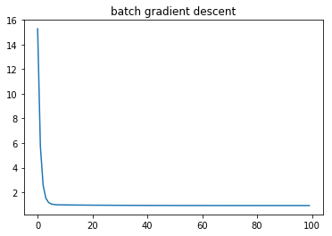

```python
# Solution
LR = 0.1
n_iter = 100
m = 100

# initialization
theta = np.random.randn(2,1)
loss = []
for i in range(n_iter):
    g = 2/m * X.T.dot(X.dot(theta)-y)
    theta = theta - LR*g
    l = 1/m*np.sum((X.dot(theta)-y)**2)
    loss.append(l)

plt.figure()
plt.plot(loss)
plt.title('batch gradient descent')
# plt.xlim([0,10])
plt.show()
```

(2) Find the fitted line with the stochastic gradient descent method and plot the loss. We use a stochastic gradient descent method to prevent the model converging to a local minimum, but the stochastic gradient descent method makes it hard to converge to a global minimum, too. To solve this problem, we are going to reduce the learning rate gradually. In other words, use a large learning rate at first and decrease it gradually.

```python
# Your code here
```

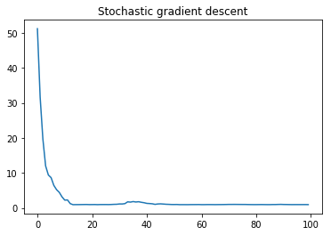

```python
# Solution
n_epochs = 1
t0, t1 = 5, 50

def LearningRate(t):
    return t0/(t+t1)

# initialization
theta = np.random.randn(2,1)

loss = []
for epoch in range(n_epochs):
    for i in range(m):
        idx = np.random.randint(m)
        xi = X[idx:idx+1]
        yi = y[idx:idx+1]
        g = xi.T.dot(xi.dot(theta)-yi)
        LR = LearningRate(epoch*m+i)
        theta = theta - LR*g
        l = 1/m*np.sum((X.dot(theta)-y)**2)
        loss.append(l)

plt.figure()
plt.plot(loss)
plt.title('Stochastic gradient descent')
# plt.xlim([0,10])
plt.show()
```

# Problem 2: Handling Overfitting

You will fit some data to the polynomial functions.

```python
import warnings
warnings.filterwarnings(action='ignore')
```

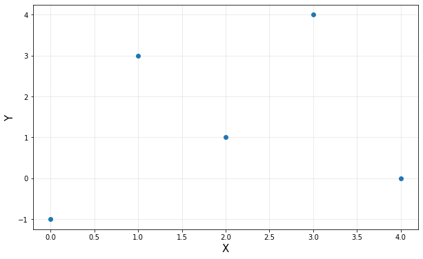

```python
import numpy as np
import matplotlib.pyplot as plt
%matplotlib inline

n = 5
x = np.linspace(0, 4, n)
y = np.array([-1, 3, 1, 4, 0])

plt.figure(figsize=(10, 6))
plt.plot(x, y, 'o')
plt.xlabel('X', fontsize = 15)
plt.ylabel('Y', fontsize = 15)
plt.grid(alpha = 0.3)
plt.show()
```

(1) Fit the given data to the 3rd degree and the 5th degree polynomials and plot both results. Use `numpy.polyfit`.

```python
# Your code here
```

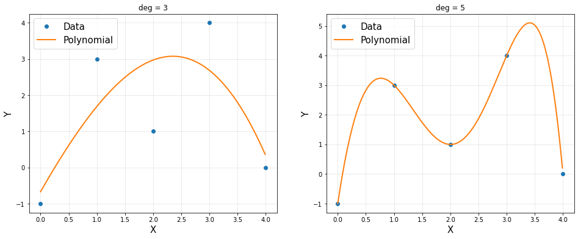

```python
# Solution

p = np.polyfit(x, y, deg = 3)
xp = np.arange(0, 4, 0.01)

plt.figure(figsize=(16, 6))
plt.subplot(121)
plt.plot(x, y, 'o', label = 'Data')
plt.plot(xp, np.polyval(p, xp), linewidth = 2, label = 'Polynomial')
plt.xlabel('X', fontsize = 15)
plt.ylabel('Y', fontsize = 15)
plt.legend(fontsize = 15)
plt.grid(alpha = 0.3)
plt.title('deg = 3')
plt.subplot(122)
p = np.polyfit(x, y, deg = n)
plt.plot(x, y, 'o', label = 'Data')
plt.plot(xp, np.polyval(p, xp), linewidth = 2, label = 'Polynomial')
plt.xlabel('X', fontsize = 15)
plt.ylabel('Y', fontsize = 15)
plt.legend(fontsize = 15)
plt.grid(alpha = 0.3)
plt.title('deg = {}'.format(n))
plt.show()
```

(2) The results of the 5th degree polynomial shows overfitting. Plot the similar figure using TensorFlow.

```python
import tensorflow as tf
from sklearn.preprocessing import MaxAbsScaler

LR = 0.4
n_iter = 10000

# Your code here
```

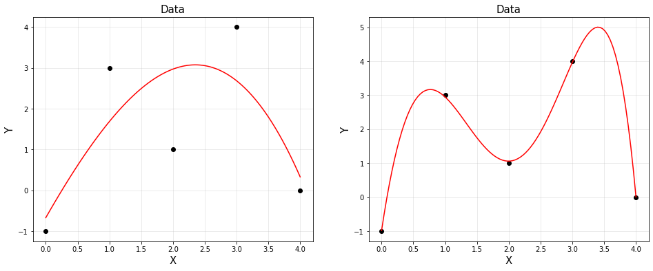

```python
import tensorflow as tf
from sklearn.preprocessing import MaxAbsScaler

LR = 0.4
n_iter = 10000

# Solution
train_x = x.reshape(-1, 1)
train_y = y.reshape(-1, 1)

def fitting(d):
    train_X = np.hstack([train_x**(i+1) for i in range(d)])
    train_X = MaxAbsScaler().fit_transform(train_X)
    train_X = np.asmatrix(train_X)

    x = tf.placeholder(tf.float32, [n, d])
    y = tf.placeholder(tf.float32, [n, 1])

    w = tf.Variable(tf.random_normal([d, 1]))
    b = tf.Variable(tf.random_normal([1, 1]))

    y_pred = tf.add(tf.matmul(x, w), b)
    loss = tf.square(y_pred - y)
    loss = tf.reduce_mean(loss)

    optm = tf.train.AdamOptimizer(LR).minimize(loss)
    init = tf.global_variables_initializer()

    loss_record = []
    with tf.Session() as sess:
        sess.run(init)
        for epoch in range(n_iter):
            sess.run(optm, feed_dict = {x: train_X, y: train_y})
            loss_record.append(sess.run(loss, feed_dict = {x: train_X, y: train_y}))

        w_val = sess.run(w)
        b_val = sess.run(b)

    Xp = np.hstack([xp**(i+1) for i in range(d)])
    Xp = MaxAbsScaler().fit_transform(Xp)
    Xp = np.asmatrix(Xp)

    yp = Xp*w_val + b_val
    return yp

xp = np.linspace(0, 4, 100).reshape(-1,1)
plt.figure(figsize=(16, 6))
plt.subplot(121)
plt.plot(train_x, train_y, 'ko')
plt.plot(xp, fitting(3), 'r')
plt.title('Data', fontsize = 15)
plt.xlabel('X', fontsize = 15)
plt.ylabel('Y', fontsize = 15)
plt.grid(alpha = 0.3)
plt.subplot(122)
plt.plot(train_x, train_y, 'ko')
plt.plot(xp, fitting(5), 'r')
plt.title('Data', fontsize = 15)
plt.xlabel('X', fontsize = 15)
plt.ylabel('Y', fontsize = 15)
plt.grid(alpha = 0.3)
plt.show()
```

(3) Avoid the overfitting by adjusting `n_iter`

```python
# Your code here
```

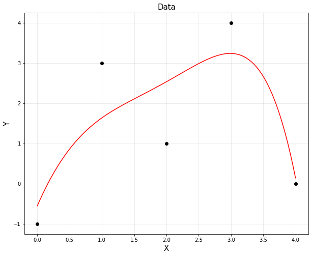

```python
# Solution
n_iter = 1000

d = 5
train_X = np.hstack([train_x**(i+1) for i in range(d)])
train_X = MaxAbsScaler().fit_transform(train_X)
train_X = np.asmatrix(train_X)

x = tf.placeholder(tf.float32, [n, d])
y = tf.placeholder(tf.float32, [n, 1])

w = tf.Variable(tf.random_normal([d, 1]))
b = tf.Variable(tf.random_normal([1, 1]))

lamb = 0.1
y_pred = tf.add(tf.matmul(x, w), b)
loss = tf.square(y_pred - y)
loss = tf.reduce_mean(loss)

optm = tf.train.AdamOptimizer(LR).minimize(loss)
init = tf.global_variables_initializer()

loss_record = []
with tf.Session() as sess:
    sess.run(init)
    for epoch in range(n_iter):
        sess.run(optm, feed_dict = {x: train_X, y: train_y})
        loss_record.append(sess.run(loss, feed_dict = {x: train_X, y: train_y}))

    w_val = sess.run(w)
    b_val = sess.run(b)

xp = np.linspace(0, 4, 100).reshape(-1,1)
Xp = np.hstack([xp**(i+1) for i in range(d)])
Xp = MaxAbsScaler().fit_transform(Xp)
Xp = np.asmatrix(Xp)
yp = Xp*w_val + b_val

plt.figure(figsize=(10,8))
plt.plot(train_x, train_y, 'ko')
plt.plot(xp, yp, 'r')
plt.title('Data', fontsize = 15)
plt.xlabel('X', fontsize = 15)
plt.ylabel('Y', fontsize = 15)
plt.grid(alpha = 0.3)
plt.show()
```

(4) Avoid the overfitting by using L1 or L2 regularization

```python
# Your code here
```

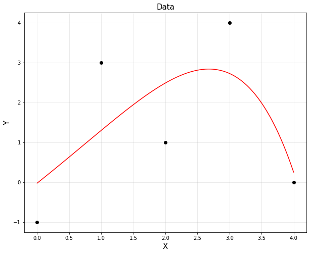

```python
# Solution
LR = 0.4
n_iter = 10000

d = 5
train_X = np.hstack([train_x**(i+1) for i in range(d)])
train_X = MaxAbsScaler().fit_transform(train_X)
train_X = np.asmatrix(train_X)

x = tf.placeholder(tf.float32, [n, d])
y = tf.placeholder(tf.float32, [n, 1])

w = tf.Variable(tf.random_normal([d, 1]))
b = tf.Variable(tf.random_normal([1, 1]))

lamb = 0.1
y_pred = tf.add(tf.matmul(x, w), b)
loss = tf.square(y_pred - y)
loss = tf.reduce_mean(loss)
reg = tf.reduce_mean(tf.norm(w, 2))
loss = tf.reduce_mean(loss + lamb*reg)

optm = tf.train.AdamOptimizer(LR).minimize(loss)
init = tf.global_variables_initializer()

loss_record = []
with tf.Session() as sess:
    sess.run(init)
    for epoch in range(n_iter):
        sess.run(optm, feed_dict = {x: train_X, y: train_y})
        loss_record.append(sess.run(loss, feed_dict = {x: train_X, y: train_y}))

    w_val = sess.run(w)
    b_val = sess.run(b)

xp = np.linspace(0, 4, 100).reshape(-1,1)
Xp = np.hstack([xp**(i+1) for i in range(d)])
Xp = MaxAbsScaler().fit_transform(Xp)
Xp = np.asmatrix(Xp)
yp = Xp*w_val + b_val

plt.figure(figsize=(10,8))
plt.plot(train_x, train_y, 'ko')
plt.plot(xp, yp, 'r')
plt.title('Data', fontsize = 15)
plt.xlabel('X', fontsize = 15)
plt.ylabel('Y', fontsize = 15)
plt.grid(alpha = 0.3)
plt.show()
```